# PDV integration in host genome

Ines Matrougui

2025-09-04

#### Overview

This R script analyzes polydnavirus (PDV) integration patterns in protostome genomes using BLAST search results.Protostome genomes are available on NCBI: https://www.ncbi.nlm.nih.gov/datasets/genome/. The analysis focuses on identifying genomic integrations mediated by Host Integration Motifs (HIMs).

This project includes an R script that processes data using a combination of:

- R code (organized into executable chunks)
- External command-line tools (Linux-based)

**System Requirements:** Linux or Unix-based OS

**Important:**

- The output of the BLAST search was produced using the following script `script_blastn_genome_arthro_vs_PDV.sh` on linux
- The workflow relies on running each R chunk individually, with manual execution of external commands in between chunks as specified in the script.

#### Purpose

To identify and characterize polydnavirus circle integrations in host genomes by:

- Filtering BLAST hits to retain those falling within Host Integration Motifs (HIMs)
- Removing false positives (low complexity regions, contamination)
- Analyzing taxonomic distribution of integrations
- Identifying orthologous integrations across species
- Performing phylogenetic analysis of integration patterns

#### Input Data

Required Files Place all input files in the `data/raw/` directory:

- `outputblastn_arthro_vs_PDV_ALL_11.txt` - Tabular BLASTN output from genome searches using `script_blastn_genome_arthro_vs_PDV.sh`
- `HIMcoord.txt` - Coordinates of HIM boundaries in PDV segments
- `seg_new_HIM.txt` - Coordinates of newly identified HIM boundaries
- `Segments.txt` - Names of PDV segments (no header)
- `PDV_wasp_sp.txt` - PDV segments with corresponding wasp species
- `id_genome_protostomia.txt` - Protostome genome identifiers from NCBI, `ncbi_dataset.tsv` https://www.ncbi.nlm.nih.gov/datasets/genome/

Place all intermediate files produced by the ancillary software (external tools) in the `data/processed/` directory:

- `taxonomy_genome.txt` - Taxonomic information (generated via efetch)
- `coor_LCR_in_hit_seg_06_12.txt` - Low complexity region coordinates
- `toMerge_merged_expand_all.txt` - Merged coordinates from bedtools
- `position_hit_merged.txt` - Position data after overlap removal
- `taxResult05_flank_tax_per_contig_read.tsv` - Metaeuk taxonomic assignment results
- `outputmegablast_ortho_flank.txt` - Megablast results for orthology analysis

#### Dependencies

R Packages used

```r
library(data.table)
library(dplyr)
library(tidyverse)
library(ggplot2)
library(igraph)
library(callr)
library(knitr)
```

External Tools Required

- **BLASTN** - For sequence similarity searches
- **bedtools** - For coordinate merging and intersection operations
- **RepeatMasker** - For low complexity region identification
- **seqtk** - For sequence extraction
- **efetch/esearch** - For sequence and taxonomy retrieval
- **metaeuk** - For taxonomic assignment of contigs
- **mmseqs2** - For clustering and database creation
- **iqtree** - For phylogenetic analysis

Utility functions

```r
# Dependency check function
check_dependencies <- function() {
  required_packages <- c("data.table", "dplyr", "tidyverse", "ggplot2", "igraph")
  missing_packages <- setdiff(required_packages, rownames(installed.packages()))

  if (length(missing_packages) > 0) {
    stop("Missing packages: ", paste(missing_packages, collapse = ", "))
  }}

check_dependencies()

# Column name cleaning function
rename_blastn_columns <- function(dt) {
  setnames(dt, paste0("V", 1:16), c(
    "query_id", "query_length", "subject_id", "subject_desc",
    "subject_length", "perc_identity", "alignment_length",
    "mismatches", "gap_opens", "query_start", "query_end",
    "subject_start", "subject_end", "evalue", "bit_score", "genome_id"
  ))
  return(dt)
}
```

#### Directory Structure

```
project/
├── data/
│   ├── raw/           # Input files
│   └── processed/     # Intermediate processed files
├── output/            # Final results and tables
├── figures/           # Phylogenies
└── src/               # R scripts
```

Path directories

```r
dir_Input <- "data/raw/"
dir_Output <- "output/"
dir_fig <- "figures/"
dir_In_processed <- "data/processed/"
script <- "src/"
```

# Integrations mediated by HIM

Import data

```r
dt=fread(paste0(dir_Input,"outputblastn_arthro_vs_PDV_ALL_11.txt"))# output blastn
HIM=fread(paste0(dir_Input, "HIMcoord.txt")) # coordinates of PDV HIM boundaries
seg=fread(paste0(dir_Input,"Segments.txt"), header=FALSE) # names of PDV
genome=read.table(paste0(dir_Input,"id_genome_protostomia.txt"), sep="\t", header = FALSE, na.strings="") # import ncbi_dataset.tsv
new_HIM=fread(paste0(dir_Input,"seg_new_HIM.txt"))# import coordinates of new PDV  HIM boundaries
PDV=fread(paste0(dir_Input,"PDV_wasp_sp.txt")) %>% distinct(segment, .keep_all = TRUE) # Name of segments with their corresponding wasp
```

```r
dt <- rename_blastn_columns(dt)
dt=dt[dt$evalue<0.0001 & dt$alignment_length>164] # filter data : identity percentage <0.0001 and hit length > 164 bp
dt <- mutate(dt, num=c(1:nrow(dt))) # add a index in order to avoid losing the row

HIM <- mutate(HIM, HIMStart=if_else(HIMstart<HIMend,HIMstart,HIMend), # put the coordinates in order
              HIMEnd=if_else(HIMstart<HIMend,HIMend,HIMstart))

#filter out all blastn hits involving segments devoid of HIM
dt_seg_HIM=dt[dt$query_id %in% HIM$SegmentName]

#number of blastn hits involving PDV devoid of HIM
dt_seg_no_HIM=dt[!(dt$query_id %in% HIM$SegmentName)]
setorder(dt_seg_no_HIM, -alignment_length)

#filter out all blastn hits involving in new HIM
dt_seg_newHIM=anti_join(dt, seg, by=c("query_id"="V1"))

#we determine the direction in which the target is aligned
dt_seg_HIM$strand=ifelse(dt_seg_HIM$subject_start < dt_seg_HIM$subject_end, "+", "-")

#add column with HIM start coordinate
dt_seg_HIM$HIMstart=HIM$HIMStart[match(dt_seg_HIM$query_id, HIM$SegmentName)]

#add column with HIM end coordinate
dt_seg_HIM$HIMend=HIM$HIMEnd[match(dt_seg_HIM$query_id, HIM$SegmentName)]

#create data table containing all blastn hits covering both HIM boundaries (we expect very few if integration is mediated by HIM)
dtHIMstart_End=dt_seg_HIM[dt_seg_HIM$query_start > dt_seg_HIM$HIMend & dt_seg_HIM$query_end < dt_seg_HIM$HIMstart | dt_seg_HIM$query_end > dt_seg_HIM$HIMend & dt_seg_HIM$query_start < dt_seg_HIM$HIMstart]

#create data table containing all blastn hits for which start or end coordinate fall between HIM start and HIM end coordinates (as expected if integration occurs through breaks within HIM)
dtHIM=dt_seg_HIM[dt_seg_HIM$query_start < dt_seg_HIM$HIMend & dt_seg_HIM$query_start > dt_seg_HIM$HIMstart | dt_seg_HIM$query_end < dt_seg_HIM$HIMend & dt_seg_HIM$query_end > dt_seg_HIM$HIMstart]

#determine which coordinate in HdIV falls in HIM
dtHIM$coordHIM=ifelse(dtHIM$query_start<dtHIM$HIMend & dtHIM$query_start>dtHIM$HIMstart, dtHIM$query_start, dtHIM$query_end)

#we determine to which junction corresponds each blastn hit based on coordinates in HdIV
dtHIM$junction=ifelse(dtHIM$query_end > dtHIM$coordHIM, "J2", "J1")

#we determine if host contig is aligned in sense or antisense orientation
dtHIM$rev=dtHIM$subject_start > dtHIM$subject_end
dtHIM$stran=ifelse(dtHIM$rev==FALSE, "+", "-")
```

# New HIM

New PDV circles from initial research using blatsn in arthropod genomes available on NCBI using the script [BlastnHIM-mediated-PDV-integrations_IM.R] These new HIMs have been added to the PDV search among protosotomians in addition to the circles already present.

```r
#we determine the direction in which the target is aligned
dt_seg_newHIM$strand=ifelse(dt_seg_newHIM$subject_start < dt_seg_newHIM$subject_end, "+", "-")

#add column with HIM start coordinate
dt_seg_newHIM$HIMstart=new_HIM$startHIMcontig[match(dt_seg_newHIM$query_id, new_HIM$query_id)]
#add column with HIM end coordinate
dt_seg_newHIM$HIMend=new_HIM$endHIMcontig[match(dt_seg_newHIM$query_id, new_HIM$query_id)]

#create data table containing all blastn hits covering both HIM boundaries (we expect very few if integration is mediated by HIM)
dtHIM_newStart_End=filter(dt_seg_newHIM, (query_start > HIMend & query_end < HIMstart) | (query_end > HIMend & query_start < HIMstart))

#create data table containing all blastn hits for which start or end coordinate fall between HIM start and HIM end coordinates (as expected if integration occurs through breaks within HIM)
dtnewHIM=filter(dt_seg_newHIM, (query_start <= HIMend & query_start >= HIMstart) | (query_end <= HIMend & query_end >= HIMstart))

#determine which coordinate in HdIV falls in HIM
dtnewHIM$coordHIM=ifelse(dtnewHIM$query_start<dtnewHIM$HIMend & dtnewHIM$query_start>dtnewHIM$HIMstart, dtnewHIM$query_start, dtnewHIM$query_end)
#we determine if host contig is aligned in sense or antisense orientation
dtnewHIM$rev=dtnewHIM$subject_start > dtnewHIM$subject_end
dtnewHIM$stran=ifelse(dtnewHIM$rev==FALSE, "+", "-")
#we determine to which junction corresponds each blastn hit based on coordinates in HdIV
dtnewHIM <- separate(dtnewHIM, query_id, into=c('PDV', 'junction', 'arthro'), sep= '-')
dtnewHIM <- tidyr::unite(dtnewHIM, col="query_id", c('PDV','arthro'), sep= '-')
#merged the HIM files and new HIM files
dtnewHIM <-  select(dtnewHIM, query_id, query_length, subject_id, subject_desc,
    subject_length, perc_identity, alignment_length,
    mismatches, gap_opens, query_start, query_end,
    subject_start, subject_end, evalue, bit_score,
    genome_id, num, strand, HIMstart, HIMend, coordHIM, junction, rev, stran)
dtHIM = rbind(dtHIM, dtnewHIM) %>%
  mutate(HIM='J1_J2_HIM')
```

# Relax the stringency at the HIM

We relax the stringency at the HIM level by accepting hits comprising an entire HIM without junctions at J1 or J2 (if the end of the hit is within 100 basis points of the end of the HIM).

```r
# Create data table to keep hits within 100 pb of the HIM
dt_seg_HIM_expand <- rbind(dt_seg_HIM, dt_seg_newHIM) %>%
  filter(!(num %in% dtHIM$num)) %>%
  mutate(HIMstart_100=HIMstart-100, HIMend_100=HIMend+100)

dtHIM_expand=filter(dt_seg_HIM_expand, (HIMstart_100 < query_start & HIMend_100 > query_start) | (HIMstart_100 < query_end & HIMend_100 > query_end) |
                      (HIMstart_100 > query_start & HIMend_100 < query_end) | (HIMstart_100 > query_end & HIMend_100 < query_start)) %>%
  mutate(coordHIM='NA',junction='NA') %>%
  select(-HIMstart_100, -HIMend_100) # add a filter to keep hits within 100 pb of the HIM

dtHIM_expand$rev=dtHIM_expand$subject_start > dtHIM_expand$subject_end # put the coordinates in order
dtHIM_expand$stran=ifelse(dtHIM_expand$rev==FALSE, "+", "-") # add the direction of the sequence

dtHIM_expand <- mutate(dtHIM_expand,HIM=if_else((query_start<HIMstart & query_end<HIMend) | (query_start>HIMstart & query_end>HIMend), "outside_HIM",
                                                if_else((query_start <= HIMstart & query_end >= HIMend) | (query_end <= HIMstart & query_start >= HIMend), "inside_HIM", "NA"))) #%>% filter(HIM!="outside_HIM") # only retain hits where there is an HIM

dtHIM <- rbind(dtHIM, dtHIM_expand)
```

# Taxonomy of genomes used

```r
#new column to get species name

#new dt to get species name
dtHIM$subject_desc=gsub(pattern = "TPA_asm: ", replacement = "", x = dtHIM$subject_desc)
species=as.data.table(tstrsplit(dtHIM$subject_desc, " ", fixed=TRUE))
species_NA=filter(species, is.na(V2)) %>%
  distinct(V1)

#add column with species name
dtHIM$gen=species$V2
dtHIM$spe=species$V3
dtHIM$genspe=paste(dtHIM$gen, dtHIM$spe, sep = "_")

setorder(dtHIM, subject_desc, -bit_score)
dtHIM_unique=dtHIM[!duplicated(dtHIM$subject_desc)]
# Species number with hit
nrow(distinct(dtHIM,genspe))
```

```
## [1] 591
```

Determine the taxonomy of genomes used extract the taxID from genomes used -> ncbi_dataset.tsv : https://www.ncbi.nlm.nih.gov/datasets/genome/

```r
# ncbi_dataset.tsv
genome <- setNames(genome, c('accession_ID', 'assembly_name', 'organism_name', 'taxoID', 'status', 'genome_length', 'assembly_level', 'date', 'WGS', 'nb_scaffold')) #%>%

genome <- as.data.table(tstrsplit(genome$accession_ID, ".", fixed=TRUE)) %>%
  cbind(select(genome, -accession_ID)) %>%
  select(-V2)
names(genome)[1] <- "accession_ID"
# extract the TaxID
taxID <- select(genome, taxoID) %>%
  distinct_all()
write.table(taxID, paste0(dir_Output,"taxID.txt"),row.names = F, col.names = F, quote = F, sep = ",")
```

Determine the taxonomy with efetch from taxID using the following commands: with the efetch software on Linux https://www.nlm.nih.gov/dataguide/edirect/efetch.html, **External commands**

```bash
# bash
efetch -db taxonomy -id taxID -format xml |   xtract -pattern Taxon -last TaxId -block "*/Taxon" -unless Rank -equals "no rank" -tab "," -sep ":"  -element Rank,ScientificName >> taxonomy_genome.txt
```

```r
# import taxonomy
taxo <- read.delim(paste0(dir_In_processed,"taxonomy_genome.txt"), sep=",", header=FALSE, fill= TRUE, na.strings="")

# edit the table to have ranks on one column
taxo_1 <- separate(taxo, V1, into=c('taxoID', 'V1'), sep= '\t')
taxo_2 <- pivot_longer(taxo_1, col=-1) %>%
  separate(value, into=c('Rank', 'taxonomy'), sep= ':') %>%
  drop_na()

# edit the table to have one column per ranks
taxo_3 <- pivot_wider(taxo_2, id_cols=taxoID, names_from = Rank, values_from = taxonomy, values_fn = list) %>%
  select(taxoID, superkingdom, kingdom, phylum, class, order, family, genus)%>%
  mutate(across(everything(), as.character))
taxo_3$taxoID <- as.integer(taxo_3$taxoID)

# fusion the genome table and the taxonomy table to have the species names of each genome
genome_taxo_all <- left_join(genome, taxo_3, by='taxoID')
genome_taxo_all <-  mutate(genome_taxo_all, genspe=str_replace(genome_taxo_all$organism_name, " ", "_")) %>%
  separate(genspe, into=c('genspe', 'plus'), sep= ' ') %>%
  select(accession_ID, superkingdom, kingdom, phylum, class, order, family, genus, genspe)
genome_taxo <-  distinct(genome_taxo_all, accession_ID, .keep_all = TRUE)
genome_taxo <- genome_taxo %>% replace(genome_taxo == "NULL", NA)
genome_taxo <- data.frame(sapply(genome_taxo, unlist))

write.table(genome_taxo, paste0(dir_Output,"genome_taxo.txt"),row.names = F, col.names = T, quote = F, sep = "\t")

# add taxonomy to hit blastn
dtHIM <-left_join(dtHIM, genome_taxo, by= c('genome_id'='accession_ID')) %>%
  select(-genspe.x)
names(dtHIM)[35] <- "genspe"
# check if all hit blastn have a taxonomy
dt_no_taxo <- filter(dtHIM,is.na(superkingdom))
```

# Identify real coordonates of hits

Identify coordonates of real integrations by distinguishing between confounding hits

```r
# create a list of contig accession numbers to download the sequence for each contig
accesion <- select(dtHIM, subject_id) %>% distinct_all()
write.table(accesion, paste0(dir_Output,"accession_number.txt"), row.names = F, col.names = F, quote = F, sep = "\t")
```

Download contigs : esearch on linux https://dataguide.nlm.nih.gov/edirect/esearch.html **External commands**

```bash
# bash
esearch -db nucleotide -query accession_number.txt | efetch -format fasta > contig.fasta
```

```r
dt_HIM2 <- mutate(dtHIM, num=c(1:nrow(dtHIM))) # add a number to each blastn hit
setorder(dt_HIM2, subject_id, bit_score) # sort hits by bitscore
dt_coor_int <-select(dt_HIM2, subject_id, subject_start, subject_end, num) %>%
  mutate(start=if_else(subject_start<subject_end, subject_start, subject_end),  # determine start and end coordinates of PDV in host contig
         end=if_else(subject_start<subject_end, subject_end, subject_start) ) %>%
  cbind(dt_HIM2[, c("bit_score", "stran")]) %>%
  select(subject_id, start, end,  num, bit_score, stran)

setorder(dt_coor_int, subject_id, start) # sort hits by bitscore
write.table(dt_coor_int, paste0(dir_Output,"toMerge_dtHIM_all_expand.txt"), row.names = F, col.names = F, quote = F, sep = "\t")
```

Create BED with name of host contig, start and end coordinate of HdIV fragment to merge them. This is to remove redundancy caused by the fact that some segments are similar to each other and thus some host PDV fragments align to both of them (e.g. Hd12 and Hd16 or BV10 and BV17)

Coordinates are merged using the following commands: dos2unix toMerge_dtHIM_all_expand.txt and bedtools on linux https://bedtools.readthedocs.io/en/latest/content/tools/merge.html **External commands**

```bash
# bash
bedtools merge -s -c 4 -o distinct -i toMerge_dtHIM_all.txt  > toMerge_merged_expand_all.txt
```

```r
merged=fread(paste0(dir_In_processed,"toMerge_merged_expand_all.txt"))
ref=as.data.table(tstrsplit(merged$V4, ",", fixed = TRUE))
names(ref)[1] <- "ref"
merged <- cbind(merged,ref[,1])#add merged start coordinate to initial dt (dtHIM)

dt_HIM2$FinalStart=merged$V2[match(dt_HIM2$num, merged$ref)]
dt_HIM2$FinalEnd=merged$V3[match(dt_HIM2$num, merged$ref)]
#remove all blastn hits that do not have merged blastn coordinates (those that have been merged with other blastn hits)
dt_HIM2=dt_HIM2[!is.na(dt_HIM2$FinalEnd)]
dtHIM=dt_HIM2

#Add J1 or J2 id the Finalstart or finalend fall between HIM start and HIM end coordinates
dtHIM <- left_join(dtHIM, select(dt_coor_int, start, end, num), by='num') %>%
  mutate(Finalstart_V10=query_start-(start-FinalStart),
         Finalend_V11=query_end+(FinalEnd-end)) # add new coordinates of the hit


dtHIM_100 <- mutate(dtHIM, start=if_else(subject_start<subject_end, subject_start, subject_end), # order coordinates
                    end=if_else(subject_start<subject_end, subject_end, subject_start)) %>%
  mutate(Finalstart_V10=query_start-(start-FinalStart),
         Finalend_V11=query_end+(FinalEnd-end)) %>%
  mutate(Finalstart_V10= if_else(Finalstart_V10<=0, 1, Finalstart_V10)) %>%
  mutate(num=c(1:nrow(dtHIM))) %>%
  mutate(HIM=if_else((Finalstart_V10 < HIMend & Finalstart_V10 > HIMstart) | (Finalend_V11 < HIMend & Finalend_V11 > HIMstart), "J1_J2_HIM", HIM)) # table of real hits

coor_hit_seg <- select(dtHIM_100, query_id, Finalstart_V10, Finalend_V11, num, strand) # coordinates of the hits

write.table(coor_hit_seg, paste0(dir_Output,"coor_hit_seg.txt"), row.names = F, col.names = F, quote = F, sep = "\t")
```

# Removal of false positives (LCRs)

Annotation of Low Complexity Regions (LCRs) representing false positives that do not originate from actual sequence homology but from low sequence complexity. All hits corresponding to LCRs are deleted.

first step: search for LCRs in segments used in initial blastn using RepeatMasker on linux https://www.repeatmasker.org/RepeatMasker/ **External commands**

```bash
# bash
RepeatMasker -low -pa 40 PDV.fas
```

second step: output the coordinates of the LCRs in the hits using bedtools intersect and coor_hit_seg.txt on linux **External commands**

```bash
# bash
bedtools intersect -a coor_hit_seg.txt -b coord_LCR_06_12.txt > coor_LCR_in_hit_seg_06_12.txt
```

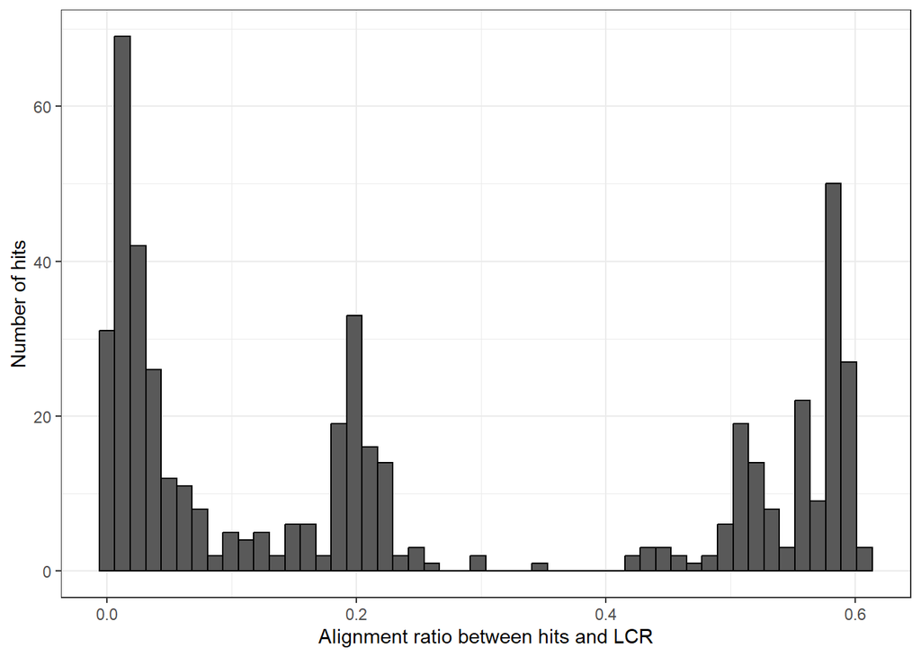

```r
# import coordinates of LCR in hits
coor_LCR_in_hit_seg <- fread(paste0(dir_In_processed,"coor_LCR_in_hit_seg_06_12.txt"))%>%
  mutate(Rep='LCR')

coor_LCR_in_hit_seg <- setnames(coor_LCR_in_hit_seg, c("query_id", "LCR_start", "LCR_end", "num","stran", "Rep")) %>%
  distinct_all() # delete if duplicate rows
coor_LCR_in_hit_seg$num <- as.integer(coor_LCR_in_hit_seg$num)

dt_LCR <- left_join(dtHIM_100, coor_LCR_in_hit_seg, by=c("num", "query_id", "stran")) %>% # add the hits table dtHIM_100
  mutate(LCR_len=LCR_end-LCR_start) %>% # calculate the length of the LCR on hits
  mutate(len= Finalend_V11-Finalstart_V10) %>%  # calculate the length of the hits
  distinct(num, .keep_all = TRUE) %>% # delete if duplicate rows
  mutate(prop_LCR= LCR_len/len) %>% # calculate the proportion of LCR relative to the hit
  mutate(prop_LCR=if_else(is.na(prop_LCR), 0, prop_LCR)) # add 0 if there is no LCR

# Histogram of the proportion of LCR relative to the hit
ggplot(filter(dt_LCR, Rep=='LCR')) + geom_histogram(aes(x=prop_LCR),color="black", bins = 50,  position = "identity") +
  theme_bw() +
  labs(x = "Alignment ratio between hits and LCR", y = "Number of hits")
```

```r
# table without hits including an LCR, without hits without HIM
dt_hits_cons <- filter(dt_LCR, is.na(Rep)) %>% # remove  LCR
  filter(HIM!='outside_HIM') %>% # remove  outside_HIM
  filter(family!='Braconidae'& family!='Ichneumonidae') # remove parasitoid wasp

# Number of species with an integration
nrow(distinct(dt_hits_cons, genspe))
```

```
## [1] 426
```

# Assignation taxonomic

```r
# flank extraction of hit integrated by J1 or J2 at 200,000 pb after the integration

contig_flank <-filter(dt_hits_cons, HIM=='J1_J2_HIM') %>% mutate(p1_meta = if_else(HIMstart<query_start & HIMend>query_start, subject_start, subject_end),
                                                  p1_meta_bis = if_else(HIMstart<query_start & HIMend>query_start, subject_end, subject_start),
                                                  p2_meta = if_else(p1_meta<p1_meta_bis, p1_meta-200000, p1_meta+200000)) %>%
  mutate(p2_meta=if_else(p2_meta<0, 1, p2_meta),
         p2_meta=if_else(p2_meta>subject_length, subject_length, p2_meta)) %>%
  mutate(start_contig=if_else(p1_meta<p2_meta, p1_meta, p2_meta),
         end_contig=if_else(p1_meta<p2_meta, p2_meta, p1_meta)) %>%
  filter(start_contig!=end_contig) %>%
  select(subject_id,start_contig, end_contig, order, family, genspe) %>%
  distinct(.keep_all = TRUE)

# flank extraction of hit with the whole HIM at 200,000 pb after the integration

#if subject_start<subject_end
contig_without_HIM_1 <- filter(dt_hits_cons, HIM=='inside_HIM') %>%
  mutate(end_contig=if_else(subject_start<subject_end, subject_start, subject_end),
         start_contig=if_else(end_contig > 200000, end_contig-200000, 1)) %>%
  filter(start_contig!=end_contig) %>%
  select(subject_id,start_contig, end_contig, order, family, genspe) %>%
  distinct(.keep_all = TRUE)

#if subject_start>subject_end
contig_without_HIM_2 <- filter(dt_hits_cons, HIM=='inside_HIM') %>%
  mutate(start_contig=if_else(subject_start>subject_end, subject_start, subject_end),
         end_contig=if_else(subject_length > start_contig+200000, start_contig+200000, subject_length))%>%
  filter(start_contig!=end_contig) %>%
  select(subject_id,start_contig, end_contig, order, family, genspe) %>%
  distinct(.keep_all = TRUE)

# merging table
contig_flank_1 <- rbind(contig_flank, contig_without_HIM_1, contig_without_HIM_2) %>%
  select(subject_id, start_contig, end_contig)

setorder(contig_flank_1, subject_id, start_contig)

write.table(contig_flank, paste0(dir_Output,"flank_contig.txt"), row.names = F, col.names = F, quote = F, sep = "\t")
```

Flank extraction using bedtools and seqtk merge on linux **External commands**

```bash
# bash
bedtools merge -i contig_flank.txt  > contig_flank_merged.txt
seqtk subseq contig.fasta flank_contig_merged.txt > flank.fasta
```

Identify the taxonomy of the flanking region to ensure that the contig is eukaryotic and not contaminated.

Metaeuk taxtocontig and mmseq2 with the NR data base on linux https://github.com/soedinglab/metaeuk?tab=readme-ov-file#taxonomic-assignment-with-taxtocontig **External commands**

```bash
mmseqs createdb nr.fasta nrdb # create a database from NR (non-redundant protein database) of NCBI https://ftp.ncbi.nlm.nih.gov/blast/db/

mmseqs createtaxdb nrdb taxDB \
  --ncbi-tax-dump ./taxdump \
  --tax-mapping-file acc2taxid.map # create a taxonomic database link to NR database

metaeuk easy-predict flank_contig.fasta nrdb predsResults_flank_NR --threads 40 tempFolder_1 # predict protein in flank sequences

metaeuk taxtocontig --threads 40 tempFolder_1/latest/contigs predsResults_flank_NR.fas predsResults_flank_NR.headersMap.tsv nrdb taxResult05_flank_NR tmpDir1 --majority 0.5 --tax-lineage 1 --lca-mode 4 # identify taxonomy of sequences base on taxonomy of predict protein
```

```r
# Import output of metaeuk taxtocontig
out_metaeuk_taxo_contig <- read_tsv(paste0(dir_In_processed,"taxResult05_flank_tax_per_contig_read.tsv"), col_names = FALSE)
# modify the names of the taxonomy to categorise them
out_metaeuk_taxo_contig <- mutate(out_metaeuk_taxo_contig, taxo=if_else(X10=="-_Monodnaviria" | X10=="-_Riboviria", 'Virus',
                                                                        if_else(X10=="d_Bacteria", 'Bacteria',
                                                                                if_else(X10=="f_Polydnaviriformidae", 'Polydnavirus',
                                                                                        if_else(X10=="d_Eukaryota", 'Eukaryota',NA))))) %>%
  separate(col=X1, c("subject_id", "autre"), sep=":")

# merges hits with taxonomy using the names of contigs in the flank table
assignation_taxo <- rbind(contig_flank, contig_without_HIM_1, contig_without_HIM_2) %>%
  distinct(subject_id, .keep_all = TRUE) %>%
  left_join(select(out_metaeuk_taxo_contig, subject_id, taxo), by=c("subject_id"))

# keep only the hits on contigs assigned to Eukaryota
filtre_assi_eucaryote <- filter(assignation_taxo, taxo=='Eukaryota')
dt_hits_cons_assi <- filter(dt_hits_cons, subject_id %in% filtre_assi_eucaryote$subject_id)
```

# Final integration table

```r
# Final number of species with an integration
nrow(distinct(dt_hits_cons_assi, genspe))
```

```
## [1] 323
```

```r
# record the final table of hits representing integrations in hosts genome
write.table(dt_hits_cons_assi, paste0(dir_Output,"dt_integration_final.txt"), row.names = F, col.names = T, quote = F, sep = "\t")
```

# Analysis of final integration table

#### Figure: phylogeny of phylum, order, and family

Figure: phylogeny to show in which phylum, order and family are species with integration

```r
rscript(paste0(script,"phylogeny_phylum_insect_order_family.R"))
```

[output not shown]

## Data for phylogeny

### Phylogeny of species

##### Choice of species

Select species for a phylogeny showing where integrations occur in the tree (presence of orthology)

```r
# list of species
list_family <- select(filter(dt_hits_cons_assi, order!='Lepidoptera'), family) %>%  distinct() # list of family with integration outside Lepidoptera
dt_species_all <- filter(genome_taxo_all, family %in% list_family$family) %>%
  select( order, family, genus, genspe) %>%
  mutate(n=0) # list of species without integration outside Lepidoptera
dt_species <- group_by(dt_hits_cons_assi, order, family, genus, genspe) %>% tally() %>%
  rbind(dt_species_all) %>%  distinct(genspe, .keep_all = TRUE) %>%
  filter(order !='Lepidoptera') %>% mutate(HT=if_else(n>0, "y", "n")) # add species with integration

# table of families with integrations outside of Lepidoptera in order to include it in the selected species
filter(dt_hits_cons_assi, order!='Lepidoptera') %>%  distinct(order, family)
```

```
##          order         family
##         <char>         <char>
## 1: Hymenoptera Tenthredinidae
## 2: Hymenoptera     Athaliidae
## 3: Hymenoptera    Diprionidae
## 4: Phasmatodea    Phasmatidae
## 5: Phasmatodea     Bacillidae
## 6:  Orthoptera  Tettigoniidae
## 7:  Coleoptera  Chrysomelidae
## 8: Hymenoptera     Cimbicidae
```

```r
# list of phasmatodea selected
list_species_Phasm <- distinct(genome_taxo_all, genspe, .keep_all = TRUE) %>% filter(order=='Phasmatodea') %>%
  head(8)
# list of orthoptera selected
list_species_Ortho <- distinct(genome_taxo_all, genspe, .keep_all = TRUE) %>% filter(order=='Orthoptera') %>%
  distinct(family, .keep_all = TRUE) %>%
  rbind(filter(distinct(genome_taxo_all, genspe, .keep_all = TRUE), genspe=="Meconema_thalassinum"| genspe=="Crioceris_asparagi"))
# liste of coleoptera
list_species_Coleo <- distinct(genome_taxo_all, genspe, .keep_all = TRUE) %>% filter(family=='Chrysomelidae') %>%
  distinct(genus, .keep_all = TRUE)
# liste of hymenoptera
list_species_Hymeno_1 <- distinct(genome_taxo_all, genspe, .keep_all = TRUE) %>%
  filter(family=='Athaliidae' | family=='Cimbicidae'|
           family=='Diprionidae'|family=='Tenthredinidae')

# liste of outgroup
out_group_1 <- distinct(genome_taxo_all, genspe, .keep_all = TRUE) %>% filter(order=='Odonata') %>% head(1)
out_group_2 <- distinct(genome_taxo_all, genspe, .keep_all = TRUE) %>% filter(order=='Diplura') %>% head(1)
out_group_3 <- distinct(genome_taxo_all, genspe, .keep_all = TRUE) %>% filter(order=='Zygentoma') %>% head(1)
out_group_4 <- distinct(genome_taxo_all, genspe, .keep_all = TRUE) %>% filter(order=='Symphypleona') %>% head(1)

# list of species selected for the phylogeny
list_species_phylo <- rbind(list_species_Phasm, list_species_Ortho, list_species_Coleo,
                             list_species_Hymeno_1,
                            out_group_1, out_group_2, out_group_3, out_group_4) %>%
  left_join(dt_species, by=c("order", "family", "genus", "genspe")) %>%
  mutate(n=if_else(is.na(n), 0, n)) %>%
  mutate(HT=if_else(is.na(HT), "n", HT)) %>%
  distinct(.keep_all = TRUE)

write.table(list_species_phylo, paste0(dir_Output,"list_species_phylo.txt"), row.names = F, col.names = T, quote = F, sep = "\t")
```

The genomes are downloaded with the script: Download_genome_phylogeny.sh

##### Number of integrations per genome

```r
# add the circle type to the integration table
dt_hits_cons_assi_PDV <-  separate(dt_hits_cons_assi, col="query_id", into=c("query_id", "sca"), sep="-") %>%
  left_join(PDV , by=c('query_id'='segment'))

# Be sure there is no redundancy
dt_hits_cons_assi_PDV_nb_hit <- distinct(dt_hits_cons_assi_PDV, subject_id, FinalStart, FinalEnd, genome_id, family, PDV, .keep_all = TRUE)

# Position of hits for tested the redundancy
position_hit <- select(dt_hits_cons_assi_PDV_nb_hit, subject_id, FinalStart, FinalEnd, num)
setorder(position_hit, subject_id, FinalStart)

write.table(position_hit, paste0(dir_Output,"position_hit.txt"), row.names = F, col.names = F, quote = F, sep = "\t")
```

Remove the last overlapping hits using bedtools on linux **External commands**

```bash
# bash
bedtools merge -i position_hit.txt -c 4 -o distinct > position_hit_merged.txt
```

```r
# Remove the last overlapping hits
position_hit_merged <- fread(paste0(dir_In_processed,"position_hit_merged.txt"))
num=as.data.table(tstrsplit(position_hit_merged$V4, ",", fixed = TRUE))
names(num)[1] <- "num"
position_hit_merged <- cbind(position_hit_merged,num[,1])#add merged start coordinate to initial dt
position_hit_merged$num <- as.numeric(position_hit_merged$num)

# number of genome by species
nb_genome_by_sp <- distinct(dt_hits_cons_assi_PDV, family, genome_id, genspe, .keep_all = TRUE) %>% group_by(family, genspe) %>% summarise(nb_genome=n())

# remouve lepidotera and standardise the names of homologous circles
nb_hit_genome_sp <- left_join(position_hit_merged, dt_hits_cons_assi_PDV_nb_hit,by="num") %>%
  filter(order!="Lepidoptera") %>%
  mutate(circles=if_else(query_id=='Hd27'|query_id=='KF156228.1_DsIV_15','IV27',
                         if_else(query_id=='H12'|query_id=='KF156246.1_DsIV_33','IV12',
                                 if_else(query_id=='H16','IV16', if_else(query_id=='Hd44.2','IV44.2',
                                 if_else(query_id=='Hd47'|query_id=='KF156251.1_DsIV_38','IV47',
                                         if_else(query_id=='AF421353.1_TrIV_F1','IVF1',
                                                 if_else(query_id=='AF421353.1_TrIV_C1'| query_id=='AY940454.1_TrIV_C1', 'IVC1',
                                                         if_else(query_id=='CfBV_S1'| query_id=='CtBV_S1','BV1',
                                                                 if_else(query_id=='CiBV_S16'|query_id=='CtBV_S16','BV16',
                                                                         if_else(query_id=='CiBV_S17'|query_id=='CtBV_S17'|query_id=='NC_006648.1_CcBV_Circle17','BV17',
                                                                                 if_else(query_id=='CtBV_S10'|query_id=='NC_006642.1_CcBV_Circle10','BV10',
                                                                                         if_else(query_id=='CtBV_S28','BV28',
                                                                                                 if_else(query_id=='NC_006649.1_CcBV_Circle18'| query_id=='CtBV_S18','BV18',
                                                                                                         if_else(query_id=='NC_006659.1_CcBV_Circle32','BV32',
                                                                                                                 if_else(query_id=='CiBV_S14'|query_id=='NC_006646.1_CcBV_Circle14','BV14',
                                                                                                                         if_else(query_id=='CtBV_S26'|query_id=='NC_006656.1_CcBV_Circle26','BV26',query_id))))))))))))))))) %>%
  group_by(family, genspe, genome_id, circles, junction) %>% tally() %>% ungroup() %>%
  group_by(family, genspe, circles, junction) %>% summarise(mean_nb_hits=mean(n)) %>%
  left_join(nb_genome_by_sp, by=c("genspe", "family")) # calculate the mean number of integration per host genome

# Export the average number of integrations per host based on circles
write.table(nb_hit_genome_sp, paste0(dir_Output,"nb_hit_genome_sp.txt"), row.names = F, col.names = T, quote = F, sep = "\t")
```

##### Clustering of hits

group similar hits together to identify intagrations shared between species

```r
# Coordinate of Jonction J1
position_hit_CLUS_J1 <- filter(dt_hits_cons_assi, junction=="J1") %>%
  select(subject_id, FinalStart, FinalEnd, stran) %>%
  mutate(FinalEnd=FinalEnd-1)

# Coordinate of Jonction J2
position_hit_CLUS_J2 <- filter(dt_hits_cons_assi, junction=="J2") %>%
  select(subject_id, FinalStart, FinalEnd, stran) %>%
  mutate(FinalEnd=FinalEnd-1)

setorder(position_hit_CLUS_J1, subject_id, FinalStart)
setorder(position_hit_CLUS_J2, subject_id, FinalStart)

write.table(position_hit_CLUS_J2, paste0(dir_Output,"position_hit_CLUS_J2.txt"), row.names = F, col.names = F, quote = F, sep = "\t")
write.table(position_hit_CLUS_J1, paste0(dir_Output,"position_hit_CLUS_J1.txt"), row.names = F, col.names = F, quote = F, sep = "\t")
```

Assigne sequences to cluster with mmseqs easy-cluster on linux **External commands**

```bash
# bash
seqtk subseq contig.fasta position_hit_CLUS_J2.txt > hit_CLUS_J2.fasta
mmseqs easy-cluster hit_CLUS_J2.fasta clustered_hit_J2_0.8_0.7 tmp --min-seq-id 0.8 -c 0.7 --cov-mode 1
```

##### Figure : phylogeny of species

Run the phylogeny_species.R script to create the figure representing the species phylogeny recorded in “figures” folder.

```r
rscript(paste0(script,"phylogeny_species.R"))
knitr::include_graphics(paste0(dir_fig,"phylogenie_species.svg"))
```

[output not shown]

### Orthology

Identify orthologous integrations shared by species by searching for similar sequences integrated into the same location in the genome

```r
##### Orthologie #####

# extract integration and the flank 5000 pb
ortho_flank <- filter(dt_hits_cons_assi, HIM=='J1_J2_HIM') %>%
  mutate(p1_meta = if_else(HIMstart<query_start & HIMend>query_start, if_else(subject_start<subject_end, FinalEnd, FinalStart), if_else(subject_start<subject_end, FinalStart, FinalEnd)),
         p1_meta_bis = if_else(HIMstart<query_start & HIMend>query_start, if_else(subject_start<subject_end, FinalStart, FinalEnd), if_else(subject_start<subject_end, FinalEnd, FinalStart)),
         p2_meta = if_else(p1_meta>p1_meta_bis, p1_meta_bis-5000, p1_meta_bis+5000)) %>%
  mutate(p2_meta=if_else(p2_meta<0, 1, p2_meta),
         p2_meta=if_else(p2_meta>subject_length, subject_length, p2_meta)) %>%
  mutate(start_contig=if_else(p1_meta<p2_meta, p1_meta, p2_meta),
         end_contig=if_else(p1_meta<p2_meta, p2_meta, p1_meta)) %>%
  mutate(relative_start_hit=if_else(p1_meta<p1_meta_bis, 1, p1_meta_bis-p2_meta), # calculate coordinate of integration and jonction
         relative_end_hit=if_else(p1_meta<p1_meta_bis, p1_meta_bis-p1_meta, p1_meta-p2_meta),
         relative_contig=if_else(p1_meta<p1_meta_bis, p2_meta-p1_meta, 1))

ortho_flank_bed <-  select(ortho_flank, subject_id, start_contig, end_contig, num) %>%
  distinct(.keep_all = TRUE)


setorder(ortho_flank_bed, subject_id, start_contig)
write.table(ortho_flank_bed, paste0(dir_Output,"ortho_flank.txt"), row.names = F, col.names = F, quote = F, sep = "\t")
```

search for similarity in integrations and flanks using megablast against itself on linux **External commands**

```bash
# bash
seqtk subseq contig.fasta ortho_flank_merged.txt > ortho_flank.fasta
blastn -task megablast -query ortho_flank.fasta -db ortho_flank.fasta -outfmt '6 qaccver qlen saccver stitle slen pident length mismatch gapopen qstart qend sstart send evalue bitscore' -num_threads 30 -evalue 0.0001 -out outputmegablast_ortho_flank.txt
```

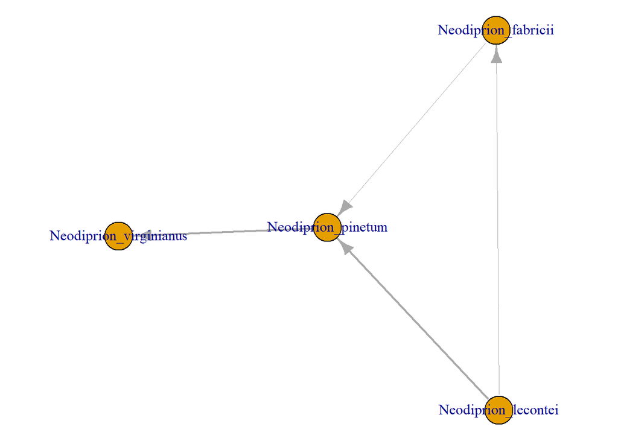

```r
megablast <- fread(paste0(dir_In_processed, "outputmegablast_ortho_flank.txt"), header = FALSE, sep='\t')
setnames(ortho_flank_bed, c("contig", "start", "end", "ref"))

# coordinates of integration and flank
ortho_flank_taxo <- left_join(ortho_flank_bed,
                              select(ortho_flank, num, query_id, order, family, genspe, relative_start_hit, relative_end_hit, relative_contig),
                              by=c("ref"="num")) %>%
                    mutate(start=start+1) %>%
                    unite("name", contig:start, sep =":") %>%
                    unite("name", name:end, sep ="-") %>%
                    select(-ref) %>%
                    distinct(name, .keep_all = TRUE)

# name of querry, species, family, order, coordinates
ortho_flank_taxo_V1 <- ortho_flank_taxo
  setnames(ortho_flank_taxo_V1, c("name", "cercle_V1", "order_V1", "family_V1", "genspe_V1", "relative_start_hit_V1", "relative_end_hit_V1", "relative_contig_V1"))

dt_megablast <- filter(megablast, V1!=V3) %>%
    left_join(ortho_flank_taxo_V1, by=c("V1"="name"))

# name of the db species, family, order, coordinates
ortho_flank_taxo_V3 <- ortho_flank_taxo
  setnames(ortho_flank_taxo_V3, c("name", "cercle_V3", "order_V3", "family_V3",  "genspe_V3", "relative_start_hit_V3", "relative_end_hit_V3", "relative_contig_V3"))

# add coordinate to ouplut of megablast
dt_megablast_1 <-  left_join(dt_megablast, ortho_flank_taxo_V3, by=c("V3"="name")) %>%
  filter(genspe_V1!=genspe_V3) %>%
  filter((relative_start_hit_V1<V10 & relative_end_hit_V1>V10) & (relative_end_hit_V1<V11 & relative_contig_V1>V11)) %>%
  filter(((relative_start_hit_V3<V12 & relative_end_hit_V3>V13) & (relative_end_hit_V3<V12 & relative_contig_V3>V12)) |
           ((relative_start_hit_V3<V13 & relative_end_hit_V3>V12) & (relative_end_hit_V3<V13 & relative_contig_V3>V13))) %>%
  mutate(len_hit_ali= relative_end_hit_V1-V10,
          len_hit= relative_end_hit_V1- relative_start_hit_V3,
         prop_hit= len_hit_ali/len_hit,
         len_contig_ali= V11-relative_end_hit_V1,
          len_contig= relative_contig_V1-relative_end_hit_V1,
         prop_contig= len_contig_ali/len_contig)

# filter : remove the Lepidoptera
# The proportion of alignment on the flank must be greater than 50% and the proportion on integration greater than 90%
dt_megablast_no_lepido <- filter(dt_megablast_1, order_V1!="Lepidoptera" & order_V3!="Lepidoptera") %>%
  filter(prop_contig > 0.5 & prop_hit > 0.9)

# calculate real position of orthology
dt_ortho_seq_1 <- separate(dt_megablast_no_lepido, col = V1,into = c("contig", "coor"), sep = ":") %>%
  separate(col = coor, into = c("start", "end"), sep = "-")%>% select(contig, start, end) %>% distinct(.,.keep_all = TRUE)

dt_ortho_seq_2 <- separate(dt_megablast_no_lepido, col = V3,into = c("contig", "coor"), sep = ":") %>%
  separate(col = coor, into = c("start", "end"), sep = "-")%>% select(contig, start, end) %>% distinct(.,.keep_all = TRUE)

dt_ortho_seq <- rbind(dt_ortho_seq_1, dt_ortho_seq_2) %>% distinct(.,.keep_all = TRUE)

write.table(dt_ortho_seq, paste0(dir_Output,"ortho_positions.txt"), row.names = F, col.names = F, quote = F, sep = "\t")

# visualised orthology connections between species
connection <- group_by(dt_megablast_no_lepido, genspe_V1, genspe_V3) %>%  summarise(Weight=n())
par(mar=c(0,0,0,0))
g=graph_from_data_frame(connection, directed=TRUE)
graph_layout=layout.fruchterman.reingold(g)
E(g)$width <- E(g)$Weight/2
plot(g,layout=graph_layout)
```

```r
write.csv(dt_megablast_no_lepido, paste0(dir_Output,"dt_no_lepido_megablast.csv")) #, quote = F, sep = ";", col.names = T)
```

### Phylogeny J1/J2

Phylogeny of a specific circle hd27/ds15 by separating J1 and J2 to understand the origin of integrations and their evolution.

```r
# We chose the Hd27 circle homologue of Ds15 the most numerous in the integration.
position_hit_Ds15_Hd27_no_Lepido <- filter(dt_hits_cons_assi, (query_id=="KF156228.1_DsIV_15" | query_id=="Hd27") & order!="Lepidoptera")

# position of the jonction J2
position_hit_Ds15_Hd27_no_Lepido_J2 <- separate(position_hit_Ds15_Hd27_no_Lepido, col="query_id", into=c("query_id", "sca"), sep="-") %>%
  filter(junction=="J2") %>%
  select(subject_id, FinalStart, FinalEnd, stran) %>%
  mutate(FinalEnd=FinalEnd-1)

# position of the jonction J1
position_hit_Ds15_Hd27_no_Lepido_J1 <- separate(position_hit_Ds15_Hd27_no_Lepido, col="query_id", into=c("query_id", "sca"), sep="-") %>%
  filter(junction=="J1") %>%
  select(subject_id, FinalStart, FinalEnd, stran) %>%
  mutate(FinalEnd=FinalEnd-1)

setorder(position_hit_Ds15_Hd27_no_Lepido_J2, subject_id, FinalStart)
setorder(position_hit_Ds15_Hd27_no_Lepido_J1, subject_id, FinalStart)

write.table(position_hit_Ds15_Hd27_no_Lepido_J2, paste0(dir_Output,"position_hit_Ds15_Hd27_no_Lepido_J2.txt"), row.names = F, col.names = F, quote = F, sep = "\t")
write.table(position_hit_Ds15_Hd27_no_Lepido_J2, paste0(dir_Output,"position_hit_Ds15_Hd27_no_Lepido_J1.txt"), row.names = F, col.names = F, quote = F, sep = "\t")
```

Extract sequences integrated from contigs on linux **External commands**

```bash
#Unix : phylogeny
#merge position :
bedtools merge -i position_hit.txt -c 4 -o distinct > position_hit_merged.txt
#sequences :
seqtk subseq contig.fasta position_hit_Ds15_Hd27_no_Lepido_J2_merged.txt > hit_Ds15_Hd27_no_Lepido_J2.fasta
```

Phylogeny J1/J2 of homologus intagration of cercle Hd27, Ds15 using iqtree on linux **External commands**

```bash
#alignement : muscle on genious
#trimmed :
/opt/bin/trimal -in hit_Ds15_Hd27_no_Lepido_J2_alignment.fasta -out hit_Ds15_Hd27_no_Lepido_J2_alignment_trimmed.fasta -automated1
#phylogeny :
/opt/anaconda3/envs/anvio5/bin/iqtree -s hit_Ds15_Hd27_no_Lepido_J2_alignment_trimmed.fasta -m MFP -bb 1000 -nt 20
```

##### Figure : phylogenu J1/J2

Run the phylogeny_J1_J2.R script to create the figure representing the phylogeny of the integrations separate by jonction (J1 and J2) recorded in “figures” folder.

```r
rscript(paste0(script,"phylogeny_J1_J2.R"))
knitr::include_graphics(paste0(dir_fig,"phylogeny_J1_Hd27_Ds15.svg"))
knitr::include_graphics(paste0(dir_fig,"phylogeny_J2_Hd27_Ds15.svg"))
```

[output not shown]

### Sequencing depth of integrations

Check the sequencing depth of integrations to ensure that they are integrations in the germline.

```r
# int_germinal

# coordinate of  in the integration 100 bp before the junction and 300 bp after the junction in the flank
int_flank <- filter(dt_hits_cons_assi, HIM=='J1_J2_HIM') %>%
  mutate(p1_meta = if_else(HIMstart<query_start & HIMend>query_start, if_else(subject_start<subject_end,  FinalStart+100, FinalEnd+100), if_else(subject_start<subject_end,  FinalEnd-100, FinalStart-100)),
         p1_meta_bis = if_else(HIMstart<query_start & HIMend>query_start, if_else(subject_start<subject_end, FinalStart,FinalEnd ), if_else(subject_start<subject_end, FinalEnd, FinalStart)),
         p2_meta = if_else(p1_meta>p1_meta_bis, p1_meta_bis-300, p1_meta_bis+300)) %>%
  mutate(p2_meta=if_else(p2_meta<0, 1, p2_meta),
         p2_meta=if_else(p2_meta>subject_length, subject_length, p2_meta)) %>%
  mutate(start_contig=if_else(p1_meta<p2_meta, p1_meta, p2_meta),
         end_contig=if_else(p1_meta<p2_meta, p2_meta, p1_meta)) %>%
  mutate(sens=if_else(p1_meta<p2_meta, "+", "-"))

# Choose species and export the coordinates of the hit/flank

genome_id_ncbi = c("GCA_032445375", "GCA_029891345", "GCA_040182645", "GCA_958507055", "GCA_963924015",
              "GCA_021155775", "GCA_021155775", "GCA_946902985", "GCA_944452905",  "GCA_958507055")
id_sp = c("Br", "Da", "Ch", "Ca", "Ma", "Np", "Mt", "Tm", "Rc", "Ca")


hit_position <- function(genome, id)
{
  hit<- filter(int_flank, genome_id==genome) %>%
  select(subject_id, start_contig, end_contig, sens)
  write.table(hit , paste0(dir_Output,"hit_position_", id, ".txt"), quote = F, sep = "\t", col.names = F, row.names = F)
}

mapply(hit_position, genome_id_ncbi, id_sp)
```

I use the script “script_depth_hits.sh” on linux to calculate the sequencing depth at the integration and flank level and “graph_depth_hit_bis.R” with R to create the figures

#Key Output Files

- `dt_integration_final.txt` - Final filtered integration table
- `list_species_phylo.txt` - Species selected for phylogenetic analysis
- `nb_hit_genome_sp.txt` - Integration counts per genome/species
- `ortho_positions.txt` - Coordinates of orthologous integrations
- `dt_no_lepido_megablast.csv` - Orthology analysis results